# Kaggle competition E_Lior

Elior Bliah & Lior Shabtai

25 May 2020

# Introduction

In this file we will predict the log of wages using some machine learning algorithms. First, we will explore the data and present data visualization. Second, we will walk through the models we have used. Afterwards, we will compare the different models based on predictive power (interpretability with DALEX). Finally, we will predict using the model we found best for our purposes.

## About PSID

Panel Study of Income Dynamics (PSID) is a panel survey of families in the US, conducted by the University of Michigan. The PSID measures economic, social, and health factors over the life course of families over multiple generations. Data have been collected from the same families and their descendants since 1968. As of 2013, the PSID had information on over 75,000 individuals, spanning as many as 4 decades of their lives. The data set we received is a subset taken from the PSID database.

# Loading the packages

```r
if (!require("pacman")) install.packages("pacman")
pacman::p_load(DataExplorer, here, readr, plyr, gridExtra, glmnet, tidymodels, kableExtra, stargazer,ROCit, caret, rsample, yardstick, tidyverse, DALEX)
```

# Loading the data

```r
urlfile1= "https://raw.githubusercontent.com/elior631/Kaggle-competition-No.1/master/train.csv"
urlfile2= "https://raw.githubusercontent.com/elior631/Kaggle-competition-No.1/master/test.csv"

train_set<- read_csv(url(urlfile1))
test_set<- read_csv(url(urlfile2))


vec <- c(3, 8:39)
train_set_viz <- train_set
train_set_viz[vec]<- lapply(train_set_viz[vec], factor)
```

## Define as factors all binary features

```r
vec <- c(3, 8:39)
train_set_viz <- train_set
train_set_corr <- train_set
train_set_viz[vec]<- lapply(train_set_viz[vec], factor)
```

# Data Visualization:

## Creating a general report using functions from DataExplorer:

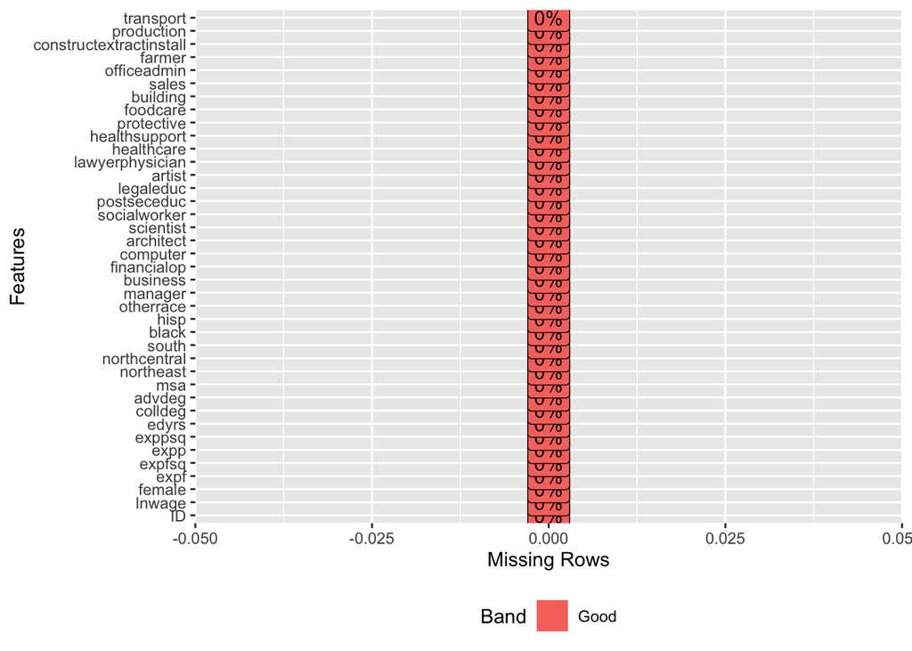

```r
plot_missing(train_set)
```

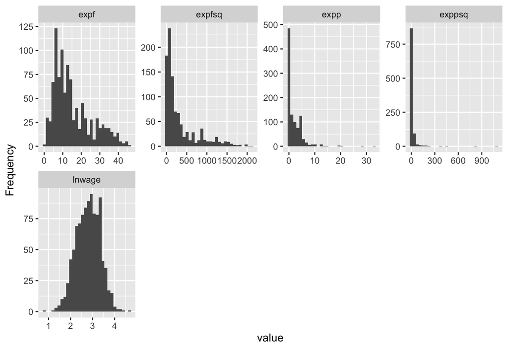

```r
train_set_viz %>%
  select(-ID) %>%
  plot_histogram()
```

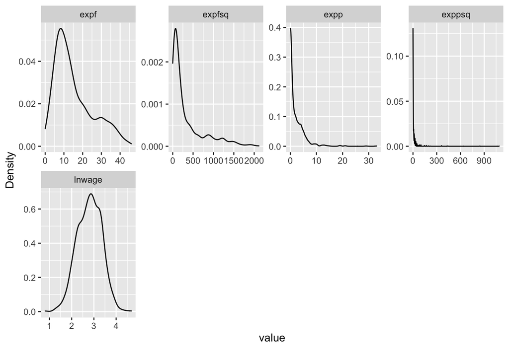

```r
train_set_viz %>%
  select(-ID) %>%
  plot_density()
```

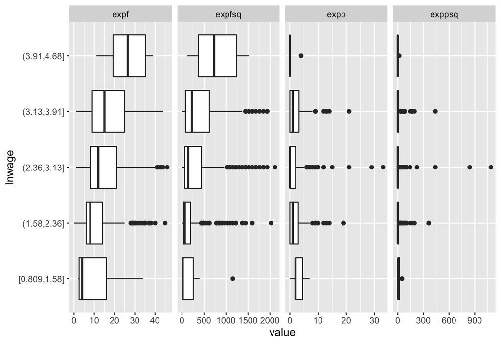

```r
train_set_viz %>%
  select(-ID) %>%
  plot_boxplot(by = "lnwage")
```

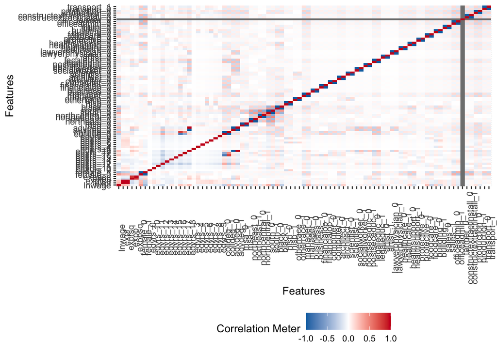

```r
train_set_viz %>%
  select(-ID) %>%
  plot_correlation()
```

We can see that we cannot learn a lot about the data from these results. we will now focus on the main features that can be used to predict wage.

### Correlation of log of wage with the main features:

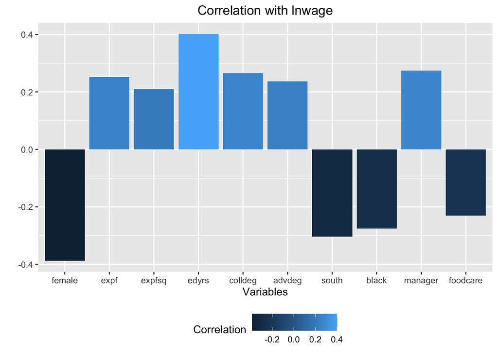

```r
correl <- train_set_corr %>%
  data.frame() %>%
  cor()

correl[lower.tri(correl,diag=TRUE)]=NA # put NA
correl<-as.data.frame(as.table(correl)) # as a dataframe
correl<-na.omit(correl) # remove NA
correl<-correl[with(correl, order(-Freq)), ]
correl<- correl[correl$Var1 == "lnwage",]

correl<- correl[correl$Freq >= 0.2 | correl$Freq <= -0.2 ,]

correl %>%
  ggplot(aes(x=Var2 , y= Freq)) +
  geom_col(aes( fill = Freq)) +
   xlab('Variables') +
 ylab('') +
  ggtitle("Correlation with lnwage") +
  labs(fill = "Correlation") +
  theme(legend.position = "bottom",
      plot.title = element_text(hjust = 0.5))
```

### Several density plots of log of wage divided by the main features:

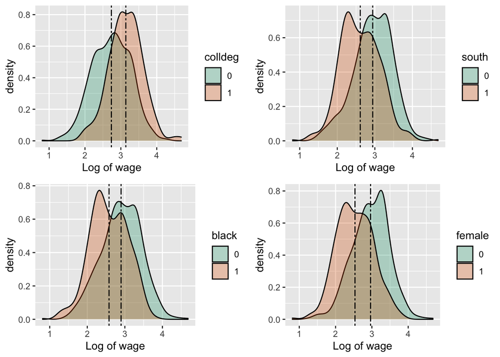

```r
log_sex_mean <- ddply(train_set_viz, "female", summarise, grp.mean=mean(lnwage))

# lnwage distribution by sex
sex_p <- train_set_viz %>%
  ggplot(aes(x = lnwage, fill = female)) +
  geom_density(alpha = 0.3) +
  geom_vline(data = log_sex_mean, aes(xintercept = grp.mean),
              linetype="twodash") +
  xlab("Log of wage") +
  scale_fill_brewer(palette="Dark2")

# lnwage distribution by black/white
log_black_mean <- ddply(train_set_viz, "black", summarise, grp.mean=mean(lnwage))

black_p<- train_set_viz %>%
  ggplot(aes(x = lnwage, fill= black)) +
  geom_density(alpha = 0.3) +
  geom_vline(data = log_black_mean, aes(xintercept = grp.mean),
             linetype="twodash") +
  xlab("Log of wage") +
  scale_fill_brewer(palette="Dark2")



log_south_mean <- ddply(train_set_viz, "south", summarise, grp.mean=mean(lnwage))

south_p <- train_set_viz %>%
  ggplot(aes(x = lnwage, fill= south)) +
  geom_density(alpha = 0.3) +
  geom_vline(data = log_south_mean, aes(xintercept = grp.mean),
             linetype="twodash") +
  xlab("Log of wage") +
  scale_fill_brewer(palette="Dark2")


log_colldeg_mean <- ddply(train_set_viz, "colldeg", summarise, grp.mean=mean(lnwage))

colldeg_p <- train_set_viz %>%
  ggplot(aes(x = lnwage, fill = colldeg)) +
  geom_density(alpha = 0.3) +
  geom_vline(data = log_colldeg_mean, aes(xintercept = grp.mean),
             linetype="twodash") +
  xlab("Log of wage") +
  scale_fill_brewer(palette="Dark2")


grid.arrange(colldeg_p, south_p, black_p, sex_p)
```

# Getting ready for the model estimation

## Interactions and variables generating

First of all, based on the analysis above, we will create several interactions and a variable for the square value of education years:

```r
train_set<- train_set %>%
  mutate(fem_edu = female*edyrs,
         fem_col = female*colldeg,
         fem_bl = female*black,
         fem_so = female*south,
         bl_so = black*south,
         bl_edu =black*edyrs,
         bl_col = black*colldeg,
         edu2 = edyrs*edyrs,
         so_edu = south*edyrs
         )


test_set<- test_set %>%
  mutate(fem_edu = female*edyrs,
         fem_col = female*colldeg,
         fem_bl = female*black,
         fem_so = female*south,
         bl_so = black*south,
         bl_edu =black*edyrs,
         bl_col = black*colldeg,
         edu2 = edyrs*edyrs,
         so_edu = south*edyrs
         )
```

## Splitting the train_set data for training and test sets:

```r
set.seed(1994)
data_split<- initial_split(train_set, prop = 0.7)
train_set1 <- training(data_split)
test_set1 <- testing(data_split)
```

```r
x_train <- train_set1[, c(3:48)] %>%
  data.matrix()
y_train <- train_set1$lnwage

x_test <- test_set1[, c(3:48)] %>%
    data.matrix()
y_test <- test_set1$lnwage

test_set_noID <- data.matrix(test_set[, c(2:47)])
```

# Models

## Ridge regularization with Cross validation

The first model we will use will be a model with ridge regularization:

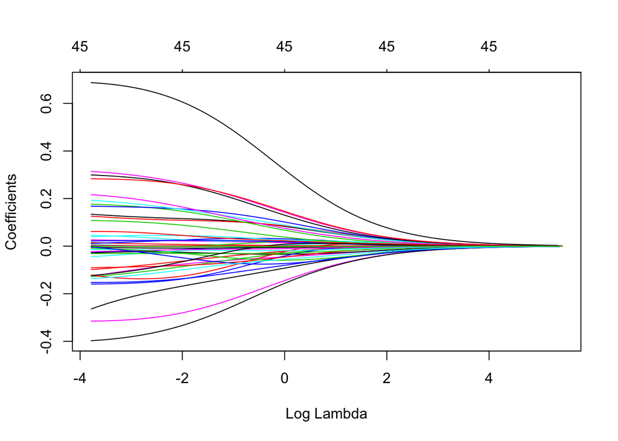

```r
fit_ridge <- glmnet(x_train, y_train, alpha = 0)
fit_ridge %>%
  plot(xvar = "lambda")
```

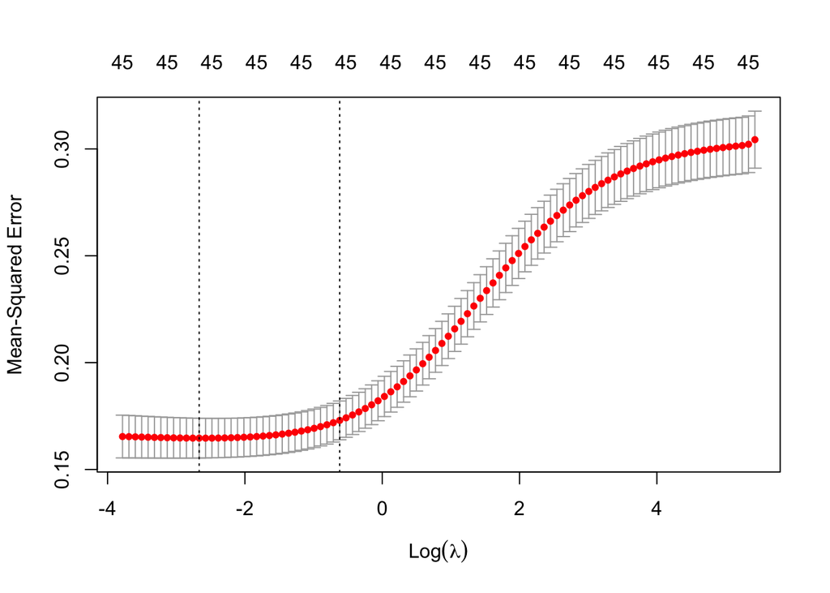

```r
cv_fit <- cv.glmnet(x_train, y_train, alpha = 0)
cv_fit %>%
  plot()
```

Picking lambda:

```r
pred_cv_min <- as.vector(predict(cv_fit, s = "lambda.min", newx = x_test))
pred_cv_1se <- as.vector(predict(cv_fit, s = "lambda.1se", newx = x_test))


comp_models <- data.frame("Min Lambda" = pred_cv_min, pred_cv_1se)

comp_models %>%
  tidy()
```

| column | n | mean | sd | median | trimmed | mad | min | max | range | skew | kurtosis | se |
| --- | --- | --- | --- | --- | --- | --- | --- | --- | --- | --- | --- | --- |
| Min.Lambda | 300 | 2.812092 | 0.4090602 | 2.819685 | 2.80702 | 0.2594332 | 1.787650 | 3.913997 | 2.126347 | 0.07006012 | 2.738205 | 0.02361710 |
| pred_cv_1se | 300 | 2.803268 | 0.3219972 | 2.817895 | 2.80324 | 0.2116047 | 2.045913 | 3.632390 | 1.586477 | -0.02435657 | 2.569318 | 0.01859052 |

Let’s have a look at the RMSE:

```r
multi_metric <- metric_set(rmse)
multi_metric(data = test_set1, truth = y_test, estimate = pred_cv_min) %>%
  tibble() %>%
  mutate(.metric = "rmse")
```

| .metric | .estimator | .estimate |
| --- | --- | --- |
| rmse | standard | 0.384801 |

Now we will run the model to predict lnwage based on the test set, using lambda.1se to avoid overfitting:

```r
pred_cv_1se_test <- as.vector(predict(cv_fit, s = "lambda.1se",
                                    newx = test_set_noID))

results <- data.frame(test_set[,1], pred_cv_1se_test) %>%
  rename("lnwage" = pred_cv_1se_test)
```

## Random Forest

The second model we will use will be random forest:

```r
formula_full <- lnwage ~ . -ID
set.seed(1994)
fitControl <- trainControl(method = "repeatedcv",
                           number = 5,
                           repeats = 3)
rf <- train(formula_full,
            data = train_set1,
            method = "rf",
            trControl = fitControl)
```

Let’s have a look at the RMSE:

```r
models_pred <- data.frame(rf = predict(rf, newdata = test_set1),
                          truth = test_set1$lnwage)

rmse(models_pred, truth, rf)
```

| .metric | .estimator | .estimate |
| --- | --- | --- |
| rmse | standard | 0.3875157 |

Predicting using the Random Forest model:

```r
pred <- predict(rf, newdata = test_set)

results_rf <- data.frame( test_set$ID, pred) %>%
  rename("lnwage" = pred)
```